# 市场观察

2017/07/31

## A、指数估值

### (a1)动态市盈率、市净率

核心指数成分股近18个月的动态市盈率及动态市净率中位数走势如下图所示：

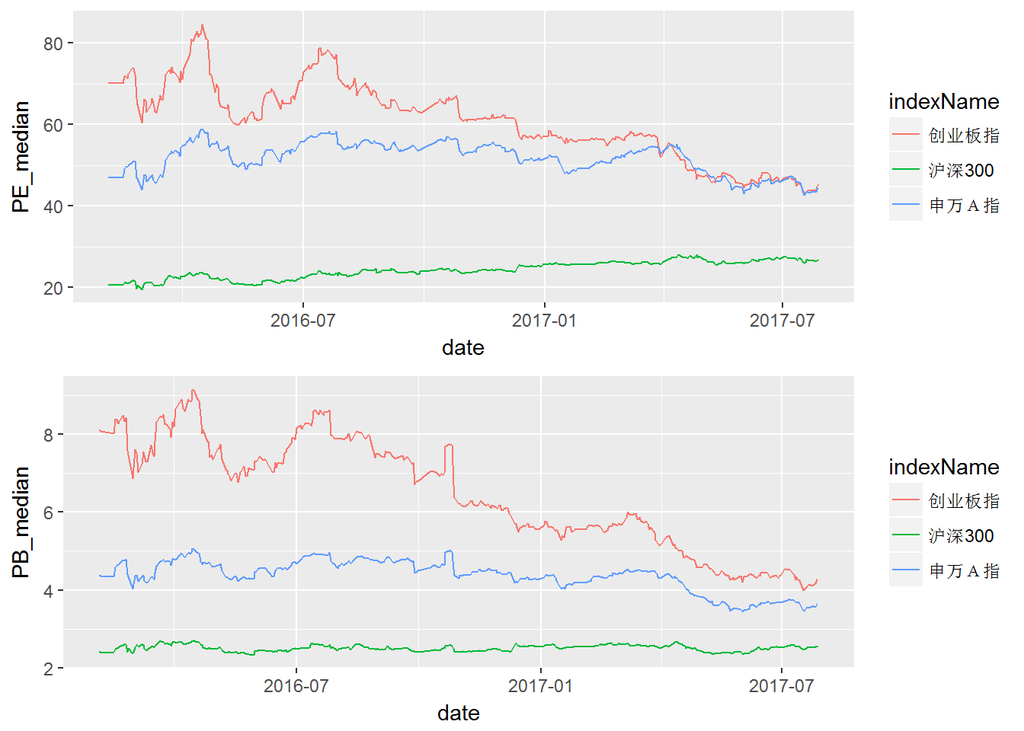

### (a2)动态市盈率、市净率百分位

核心指数近18个月的动态市盈率百分位及动态市净率百分位走势如下图所示：

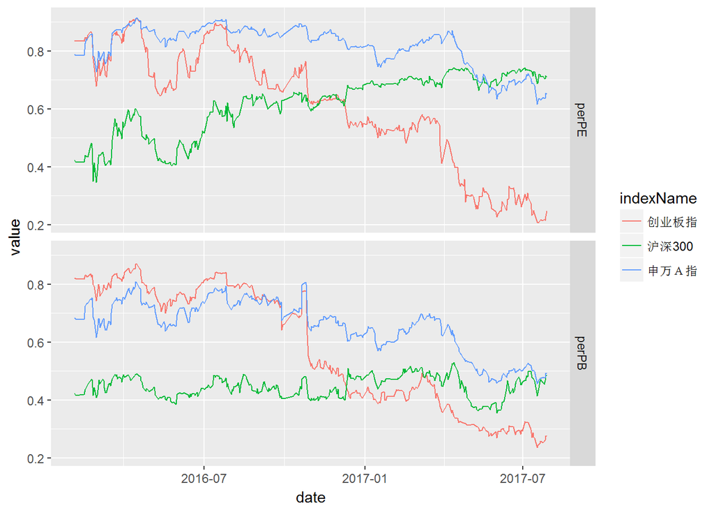

### (a3)指数估值概览

纳入观察的指数最新的估值情况如下表，根据市盈率和市净率分位数均值降序排列。

| 指数代码 | 指数简称 | 日期 | 动态市盈率 | 市盈率百分位 | 动态市净率 | 市净率百分位 |
| --- | --- | --- | --- | --- | --- | --- |
| EI000819 | 有色金属 | 2017-07-28 | 62.7 | 85% | 3.6 | 65% |
| EI000979 | 大宗商品 | 2017-07-28 | 40.0 | 76% | 2.7 | 59% |
| EI000300 | 沪深300 | 2017-07-28 | 26.6 | 71% | 2.6 | 49% |
| EI801003 | 申万Ａ指 | 2017-07-28 | 44.1 | 65% | 3.6 | 49% |
| EI399330 | 深证100 | 2017-07-28 | 33.2 | 68% | 3.5 | 44% |
| EI399959 | 军工指数 | 2017-07-28 | 81.1 | 54% | 3.9 | 46% |
| EI399005 | 中小板指P | 2017-07-28 | 39.3 | 57% | 4.3 | 36% |
| EI000934 | 中证金融 | 2017-07-28 | 19.4 | 65% | 1.8 | 18% |
| EI000905 | 中证500 | 2017-07-28 | 35.9 | 48% | 2.8 | 31% |
| EI000998 | 中证TMT | 2017-07-28 | 41.9 | 41% | 3.6 | 29% |
| EI000016 | 上证50 | 2017-07-28 | 16.9 | 53% | 1.6 | 17% |
| EI000932 | 中证消费 | 2017-07-28 | 31.0 | 44% | 3.8 | 25% |
| EI000922 | 中证红利 | 2017-07-28 | 16.3 | 40% | 1.7 | 21% |
| EI000827 | 中证环保 | 2017-07-28 | 35.1 | 27% | 3.0 | 27% |
| EI399006 | 创业板指 | 2017-07-28 | 45.5 | 25% | 4.3 | 28% |
| EI000933 | 中证医药 | 2017-07-28 | 31.8 | 16% | 3.6 | 1% |

### (a4)另类估值

我国10年期国债收益率、金银比价、金油比价，2000年以来的历史百分位如下图所示：

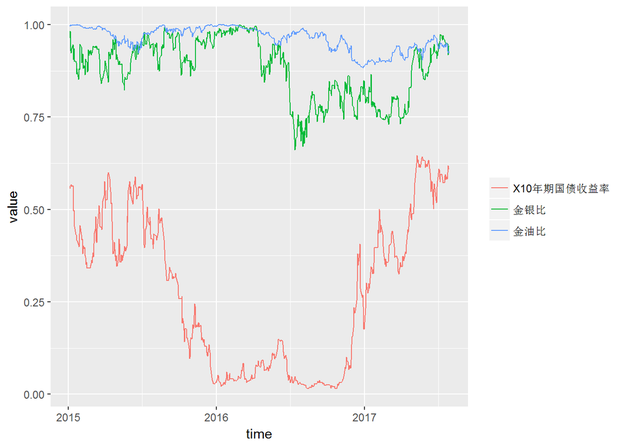

## B、基差及市场情绪

### (b1)基差走势

三大股指期货合约基差走势如下图，其中当月合约和次月合约年化基差百分比波动较大，仅展示合约基差百分比，当季合约和次季合约展示基差年化百分比：

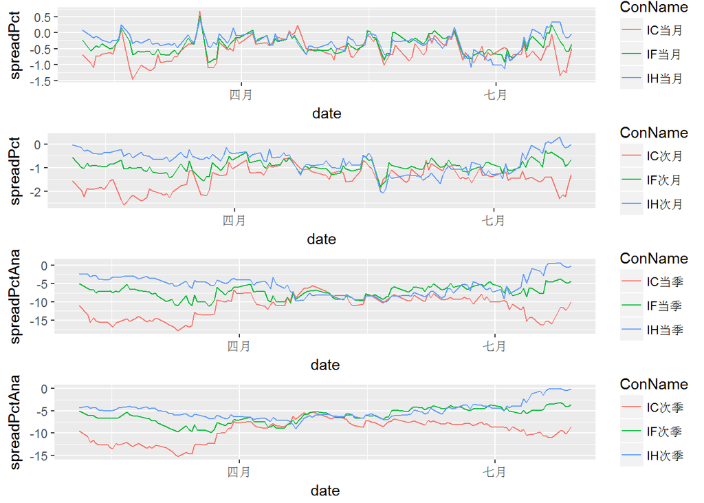

### (b2)基差概况

三大股指期货连续合约基差概况如下表，近月合约临近到期日，年化基差百分比数据波动较大：

| 日期 | 合约代码 | 合约收盘价 | 指数收盘价 | 基差 | 基差百分比 | 年化基差百分比 |
| --- | --- | --- | --- | --- | --- | --- |
| 2017-07-28 | IC1708 | 6185.2 | 6215.5 | -30.3 | -0.5% | -8.8% |
| 2017-07-28 | IC1709 | 6135.6 | 6215.5 | -79.9 | -1.3% | -10.0% |
| 2017-07-28 | IC1712 | 5988.0 | 6215.5 | -227.5 | -3.7% | -9.8% |
| 2017-07-28 | IC1803 | 5883.0 | 6215.5 | -332.5 | -5.3% | -8.6% |
| 2017-07-28 | IF1708 | 3708.4 | 3721.9 | -13.5 | -0.4% | -6.5% |
| 2017-07-28 | IF1709 | 3698.0 | 3721.9 | -23.9 | -0.6% | -4.9% |
| 2017-07-28 | IF1712 | 3661.6 | 3721.9 | -60.3 | -1.6% | -4.3% |
| 2017-07-28 | IF1803 | 3637.2 | 3721.9 | -84.7 | -2.3% | -3.6% |
| 2017-07-28 | IH1708 | 2635.6 | 2636.4 | -0.8 | -0.0% | -0.5% |
| 2017-07-28 | IH1709 | 2636.6 | 2636.4 | 0.2 | 0.0% | 0.1% |
| 2017-07-28 | IH1712 | 2635.0 | 2636.4 | -1.4 | -0.1% | -0.1% |
| 2017-07-28 | IH1803 | 2635.0 | 2636.4 | -1.4 | -0.1% | -0.1% |

### (b3)市场情绪(provided by han.qian)

市场情绪记录近60天每天自然涨跌停(剔除一字板)、创60日新高新低、多头排列空头排列(均线组合5,30,60,120)的股票数。

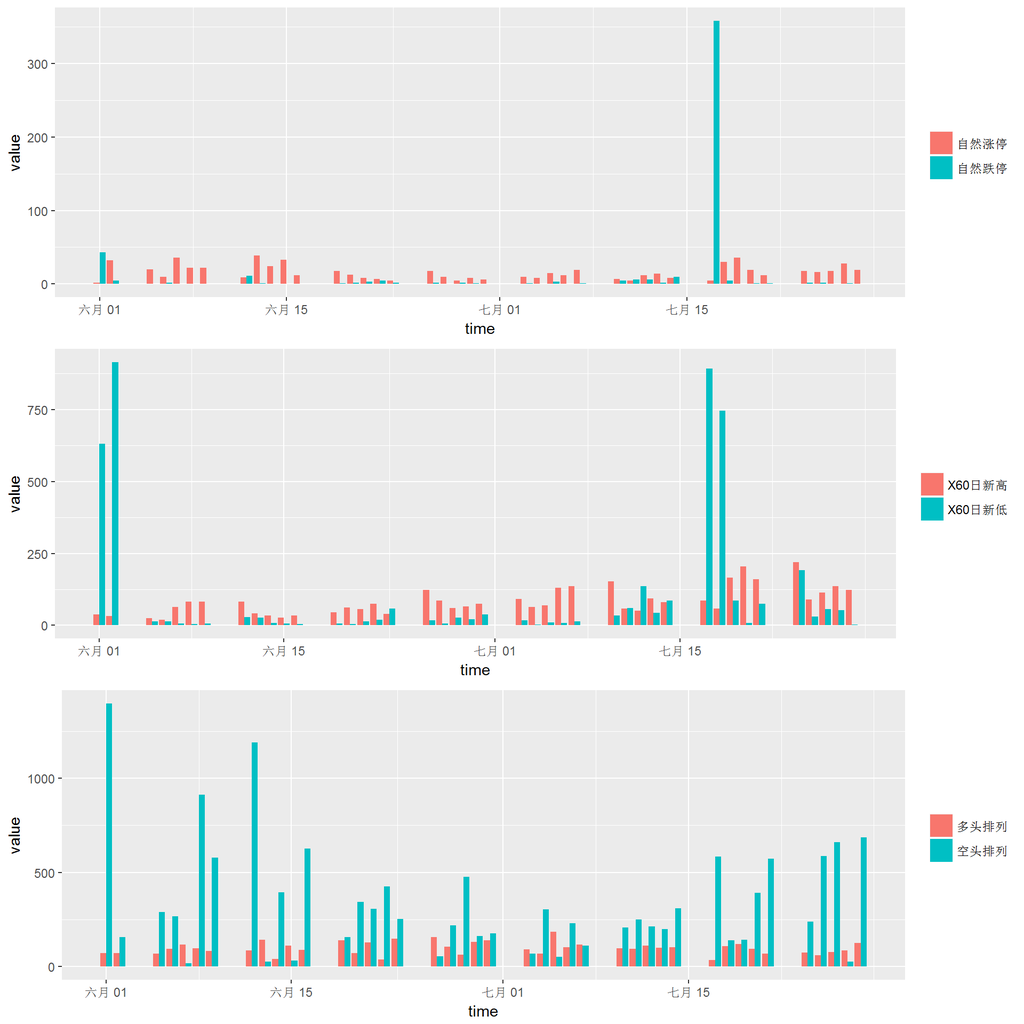

## C、套利和事件

### (c1)复牌股票套利

近两天复牌股票套利情况如下表：

[1] “No Arbitrage!”

### (c2)解禁

解禁分成两个部分，定增解禁和IPO解禁，涨跌幅记录是过去十个交易日的股票涨跌幅和对应行业指数涨跌幅。伴随着去年下半年IPO逐步正常化，今后IPO解禁给市场造成的抛压会持续存在，所以纳入观察。近期定增解禁的股票情况如下表。

| 股票代码 | 股票简称 | 解禁日 | 解禁数量 | 解禁百分比 | 区间涨跌幅 | 所属行业指数 | 行业指数涨跌幅 |
| --- | --- | --- | --- | --- | --- | --- | --- |
| EQ000408 | 藏格控股 | 2017-08-02 | 0.61 | 24% | 4.5% | 申万商业贸易 | 0.2% |
| EQ600185 | 格力地产 | 2017-08-03 | 4.42 | 27% | 3.5% | 申万房地产 | -0.1% |
| EQ002157 | 正邦科技 | 2017-08-03 | 4.96 | 36% | 6.3% | 申万农林牧渔 | -1.7% |
| EQ601901 | 方正证券 | 2017-08-08 | 19.42 | 31% | -3.0% | 申万非银金融 | -0.5% |
| EQ300158 | 振东制药 | 2017-08-10 | 1.47 | 51% | 7.8% | 申万医药生物 | -2.4% |
| EQ002149 | 西部材料 | 2017-08-11 | 0.76 | 22% | 9.1% | 申万有色金属 | 7.7% |
| EQ600577 | 精达股份 | 2017-08-14 | 5.36 | 38% | 3.8% | 申万机械设备 | -1.5% |

近期IPO解禁的股票情况如下表。

| 股票代码 | 股票简称 | 解禁日 | 解禁数量 | 解禁百分比 | 区间涨跌幅 | 所属行业指数 | 行业指数涨跌幅 | 上市日 |
| --- | --- | --- | --- | --- | --- | --- | --- | --- |
| EQ603663 | 三祥新材 | 2017-08-01 | 0.16 | 46% | -3.8% | 申万有色金属 | 7.7% | 2016-08-01 |
| EQ603111 | 康尼机电 | 2017-08-01 | 3.52 | 92% | 11.2% | 申万机械设备 | -1.5% | 2014-08-01 |
| EQ300388 | 国祯环保 | 2017-08-01 | 1.23 | 72% | 3.4% | 申万公用事业 | -0.8% | 2014-08-01 |
| EQ300389 | 艾比森 | 2017-08-01 | 0.25 | 26% | 2.7% | 申万电子 | 0.4% | 2014-08-01 |
| EQ300391 | 康跃科技 | 2017-08-01 | 1.05 | 170% | 10.5% | 申万机械设备 | -1.5% | 2014-08-01 |
| EQ600919 | 江苏银行 | 2017-08-02 | 46.40 | 402% | -5.8% | 申万银行 | 1.4% | 2016-08-02 |
| EQ300529 | 健帆生物 | 2017-08-02 | 0.64 | 152% | 2.7% | 申万医药生物 | -2.4% | 2016-08-02 |
| EQ300526 | 中潜股份 | 2017-08-02 | 0.17 | 41% | 2.0% | 申万纺织服装 | -1.6% | 2016-08-02 |
| EQ300528 | 幸福蓝海 | 2017-08-08 | 0.73 | 78% | 2.2% | 申万传媒 | -0.4% | 2016-08-08 |
| EQ601811 | 新华文轩 | 2017-08-08 | 1.00 | 102% | 2.6% | 申万传媒 | -0.4% | 2016-08-08 |
| EQ603609 | 禾丰牧业 | 2017-08-08 | 4.13 | 99% | -0.7% | 申万农林牧渔 | -1.7% | 2014-08-08 |
| EQ600977 | 中国电影 | 2017-08-09 | 0.98 | 21% | 7.7% | 申万传媒 | -0.4% | 2016-08-09 |
| EQ300531 | 优博讯 | 2017-08-09 | 0.52 | 74% | -8.2% | 申万通信 | -2.4% | 2016-08-09 |
| EQ300530 | 达志科技 | 2017-08-09 | 0.04 | 20% | 0.8% | 申万化工 | 2.2% | 2016-08-09 |
| EQ603569 | 长久物流 | 2017-08-10 | 0.17 | 43% | -2.4% | 申万交通运输 | 0.7% | 2016-08-10 |
| EQ300535 | 达威股份 | 2017-08-14 | 0.17 | 112% | -0.5% | 申万化工 | 2.2% | 2016-08-12 |
| EQ002808 | 苏州恒久 | 2017-08-14 | 0.41 | 86% | 17.8% | 申万电子 | 0.4% | 2016-08-12 |
| EQ600936 | 广西广电 | 2017-08-14 | 8.96 | 299% | 2.8% | 申万传媒 | -0.4% | 2016-08-15 |

### (c3)中小板业绩预增预测(provided by han.qian)

中小板规定正式财务报告发布的同时需要发布新一期的业绩预报，比如年报中会包含一季报预告的情况。我们假设公司的盈利状况有动量效应，年报预增的公司一季度也会预增，在正式财务报告发布前20个交易日开始埋伏，然后等正式报告发布日卖出。具体研究参见钱瀚前期的研究。需要注意的是这里的收益率仅做展示，仅仅是每日全部入选股票的平均收益率，并没有做成一个事件组合。

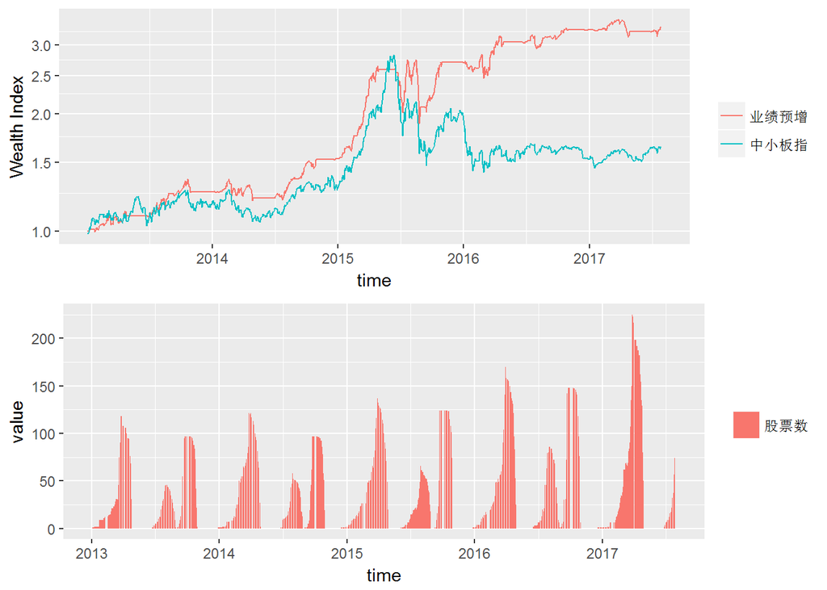

历年收益统计如下表所示。

|  | 业绩预增 | 中小板指 |
| --- | --- | --- |
| 2013-01-04 ~ 2013-12-31 | 26.0% | 17.5% |
| 2014-01-02 ~ 2014-12-31 | 21.7% | 9.7% |
| 2015-01-05 ~ 2015-12-31 | 76.7% | 53.7% |
| 2016-01-04 ~ 2016-12-30 | 21.5% | -22.9% |
| 2017-01-03 ~ 2017-07-28 | 1.9% | 8.1% |
| Cumulative Return | 235.4% | 65.1% |
| Annualized Return | 30.3% | 11.6% |